# ANOVA Example

# Problem Statement

Sometimes when reading esoteric prose we have a hard time comprehending what the author is trying to convey. A student project group decided to partially replicate part of a seminal 1972 study by Bransford and Johnson on memory encoding (“Contextual prerequisites for understanding: Some investigations of comprehension and recall,” *Journal of Verbal Learning and Verbal Behavior*, 11, pp. 717-726). The study examined college students’ comprehension of following ambiguous prose passage.

> If the balloons popped, the sound wouldn’t be able to carry since everything would be too far away from the correct floor. A closed window would also prevent the sound from carrying, since most buildings tend to be well insulated. Since the whole operation depends on a steady flow of electricity, a break in the middle of the wire would also cause problems. Of course, the fellow could shout, but the human voice is not loud enough to carry that far. An additional problem is that a string could break on the instrument. Then there could be no accompaniment to the message. It is clear that the best situation would involve less distance. Then there would be fewer potential problems. With face to face contact, the least number of things could go wrong. (p. 719)

Did you understand what the passage was describing? Would it help to have a picture? The picture that goes along with the passage is shown below:

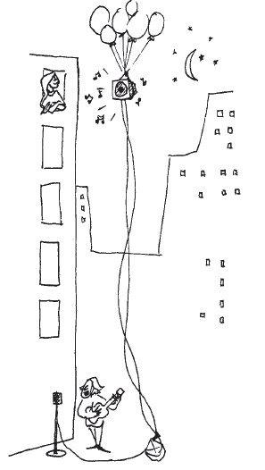

Pic

Before the college students were tested to see whether they understood the passage, they were randomly assigned to one of three groups, and then each group was read the passage under one of the following cue conditions:

- Students were shown the picture before they heard the passage.
- Students were shown the picture after they heard the passage.
- Students were not shown any picture before or after hearing the passage.

Is student comprehension of an ambiguous prose passage affected by viewing a picture designed to aid them in their understanding either before or after or not at all? So our research conjecture might be: The long-run mean comprehension score differs among the three treatments.

Fifty-seven randomly selected students were randomly assigned to be in one of the three groups with nineteen in each group. After hearing the passage under the assigned cue condition, they were given a test and their comprehension of the passage was graded on a scale of 1 to 7 with 7 being the highest level of comprehension. Note that the data collected from this study design will not be paired, but will be independent, with the outcomes in one treatment group not affecting the outcomes in the other treatment groups. (Tweaked a bit from Tintle et al. 2014 [Chapter 9])

# Competing Hypotheses

## In words

- Null hypothesis: The long-run mean comprehension scores are the same under all three cue conditions (after, before, none).
- Alternative hypothesis: At least one of the long-run mean comprehension scores is different.

## Another way with words

- Null hypothesis: There is no association between when/whether a picture is shown and student comprehension of this passage in the population of interest.
- Alternative hypothesis: There is an association between the variables in the population.

## In symbols (with annotations)

- $H_0: \mu_{after} = \mu_{before} = \mu_{none}$, where $\mu$ represents the long-run mean comprehension score.
- $H_A$: At least one of these parameter means is different from the others

## Set $\alpha$

It’s important to set the significance level before starting the testing using the data. Let’s set the significance level at 5% here.

# Exploring the sample data

```r
comp <- read.table("comprehension.txt", header = TRUE) |>
  as_tibble()
```

```r
comp_summ <- comp |>
  group_by(Condition) |>
  summarize(sample_size = n(),
    mean = mean(Comprehension),
    sd = sd(Comprehension),
    minimum = min(Comprehension),
    lower_quartile = quantile(Comprehension, 0.25),
    median = median(Comprehension),
    upper_quartile = quantile(Comprehension, 0.75),
    max = max(Comprehension))
kable(comp_summ)
```

| Condition | sample_size | mean | sd | minimum | lower_quartile | median | upper_quartile | max |
| --- | --- | --- | --- | --- | --- | --- | --- | --- |
| After | 19 | 3.21 | 1.40 | 1 | 2.0 | 3 | 4 | 6 |
| Before | 19 | 4.95 | 1.31 | 2 | 4.0 | 5 | 6 | 7 |
| None | 19 | 3.37 | 1.26 | 1 | 2.5 | 3 | 4 | 6 |

The boxplot below also shows the mean for each group highlighted by the red dots.

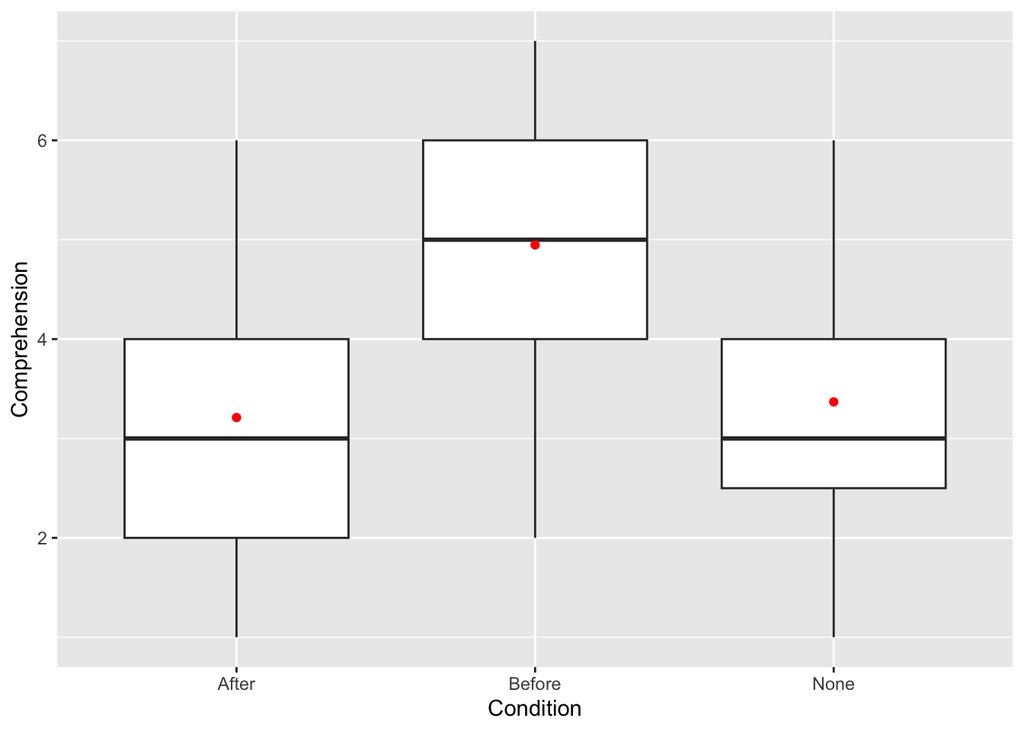

```r
comp |> ggplot(aes(x = Condition, y = Comprehension)) +
  geom_boxplot() +
  stat_summary(fun = "mean", geom = "point", color = "red")
```

## Guess about statistical significance

We are looking to see if a difference exists in the mean comprehension of the three levels of the explanatory variable. Based solely on the boxplot, we have reason to believe that a difference exists, but the overlap of the boxplots is a bit concerning.

# Non-traditional methods

We’ll use the **`infer`** package to carry out the simulation-based workflow with the $F$ statistic, the ratio of between-group to within-group variability.

## Observed statistic

```r
F_hat <- comp |>
  specify(Comprehension ~ Condition) |>
  hypothesize(null = "independence") |>
  calculate(stat = "F")
F_hat
```

```
## Response: Comprehension (numeric)
## Explanatory: Condition (factor)
## Null Hypoth...
## # A tibble: 1 × 1
##    stat
##   <dbl>
## 1  10.0
```

## Randomization for Hypothesis Test

Under the null of no association, the `Condition` labels are exchangeable, so `infer` shuffles them with `hypothesize(null = "independence")` and recomputes the $F$ statistic 10,000 times to build the null distribution.

```r
set.seed(2018)
null_distn <- comp |>
  specify(Comprehension ~ Condition) |>
  hypothesize(null = "independence") |>
  generate(reps = 10000, type = "permute") |>
  calculate(stat = "F")
```

A big $F$ ratio corresponds to between-group variability over-powering within-group variability, so this is a one-sided (right-tailed) test.

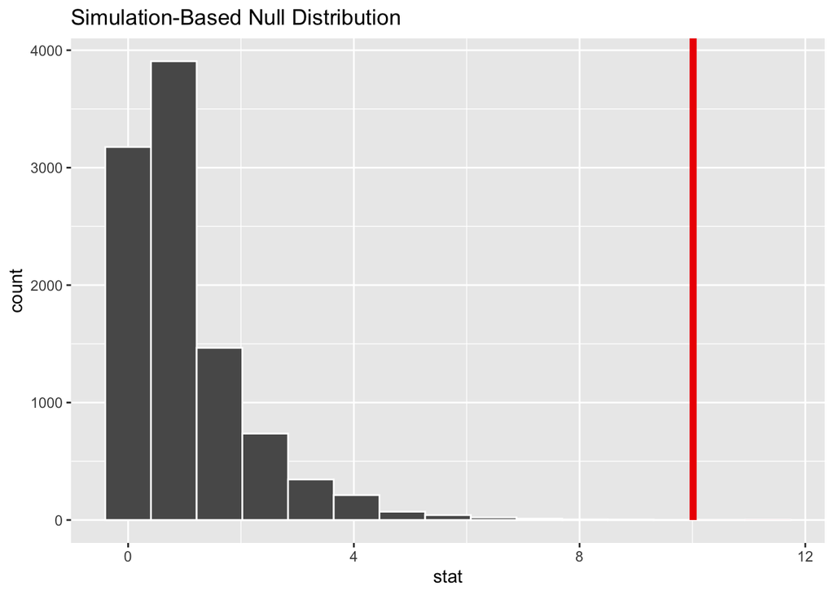

```r
null_distn |>
  visualize() +
  shade_p_value(obs_stat = F_hat, direction = "greater")
```

We can also overlay the theoretical $F$ distribution to compare the simulation-based and theory-based null distributions:

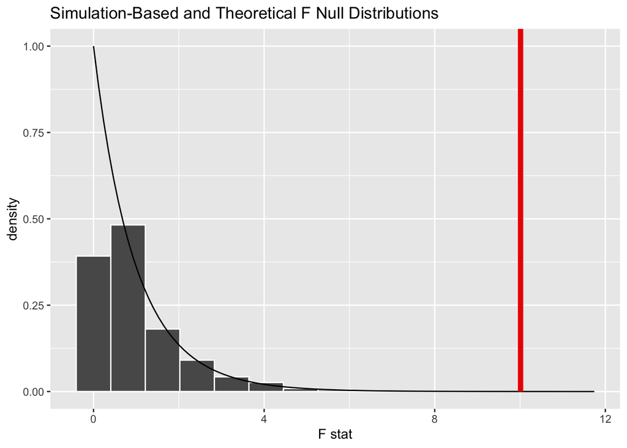

```r
null_distn |>
  visualize(method = "both") +
  shade_p_value(obs_stat = F_hat, direction = "greater")
```

### Calculate $p$-value

```r
pvalue <- null_distn |>
  get_p_value(obs_stat = F_hat, direction = "greater")
pvalue
```

```
## # A tibble: 1 × 1
##   p_value
##     <dbl>
## 1  0.0003
```

# Traditional methods

## Check conditions

Remember that in order to use the short-cut (formula-based, theoretical) approach, we need to check that some conditions are met.

1. *Independent observations*: The observations are independent both within and across groups.

   This condition is met since students were randomly assigned to be in one of the three groups and were initially randomly selected to be a part of the study.
2. *Approximately normal*: The distribution of the response for each group should be normal or the sample sizes should be at least 30.

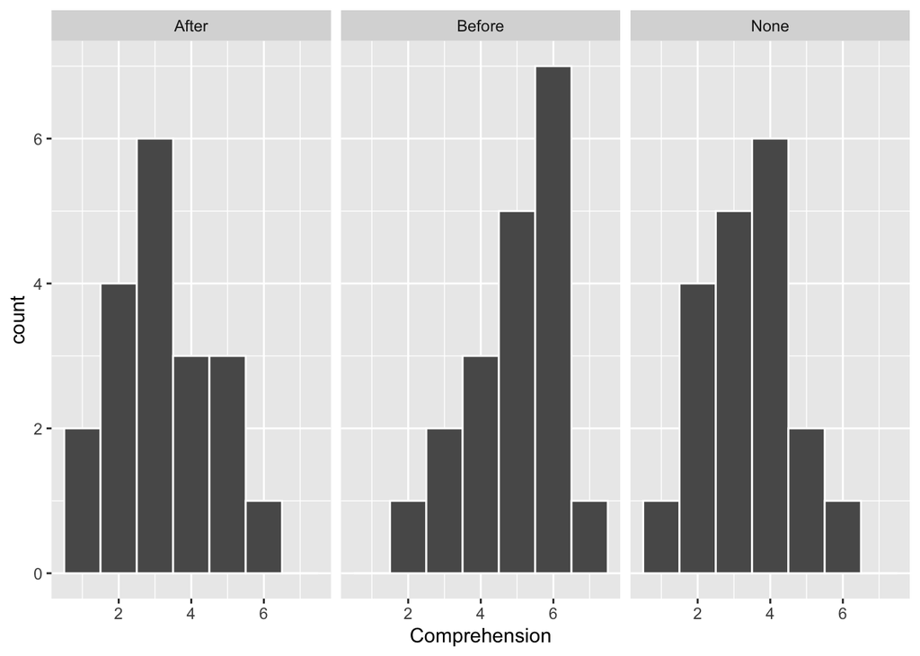

```r
comp |> ggplot(aes(x = Comprehension)) +
  geom_histogram(binwidth = 1, color = "white") +
  facet_wrap(~ Condition)
```

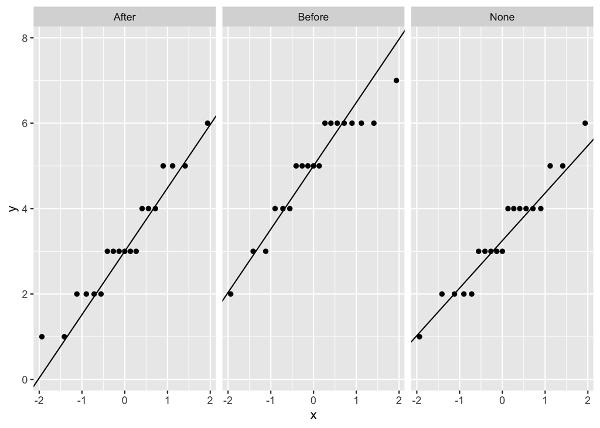

```r
comp |> ggplot(aes(sample = Comprehension)) +
  stat_qq() + stat_qq_line() +
  facet_wrap(~ Condition)
```

We have some reason to doubt the normality assumption here since both the histograms and the Q-Q plots show some deviation from a normal model fitting the data well for each group.

3. *Constant variance*: The variance in the groups is about equal from one group to the next.

   This is met by observing the table above. The `sd` values are all relatively close and the sample sizes are identical.

## Test statistic

The $F$ statistic is the ratio

$$F = \frac{MSG}{MSE},$$

where $MSG$ measures the **between** group variability

$$MSG = \dfrac{\sum_{i = 1}^k n_i
(\bar{X}_i - \bar{X})^2}{k - 1}$$

with $\bar{X}_i$ the mean for each group $i$ and $\bar{X}$ the overall mean, and $MSE$ is a pooled estimate of the **within** group variability

$$MSE = \dfrac{\sum_{i, j} (X_{ij} -
\bar{X}_j)^2}{n_{total} - k}.$$

## Observed test statistic

We fit the model with `lm()` and summarize it with the **`moderndive`** package. `get_regression_table()` shows the estimated group differences, while `get_regression_summaries()` reports the overall $F$ statistic and $p$-value — which for a single categorical predictor is exactly the one-way ANOVA $F$-test.

```r
comp_mod <- lm(Comprehension ~ Condition, data = comp)
get_regression_table(comp_mod)
```

```
## # A tibble: 3 × 7
##   term             estimate std_error statistic p_value lower_ci upper_ci
##   <chr>               <dbl>     <dbl>     <dbl>   <dbl>    <dbl>    <dbl>
## 1 intercept           3.21      0.304    10.6     0        2.60      3.82
## 2 Condition-Before    1.74      0.429     4.05    0        0.876     2.60
## 3 Condition-None      0.158     0.429     0.368   0.714   -0.703     1.02
```

```r
get_regression_summaries(comp_mod)
```

```
## # A tibble: 1 × 9
##   r_squared adj_r_squared   mse  rmse sigma statistic p_value    df  nobs
##       <dbl>         <dbl> <dbl> <dbl> <dbl>     <dbl>   <dbl> <dbl> <dbl>
## 1     0.271         0.243  1.66  1.29  1.32      10.0       0     2    57
```

We see that the `statistic` (the observed $F$ value) matches the `F_hat` computed with `infer` above, with $df_G = k - 1 = 3 - 1 = 2$ between-group degrees of freedom and $df_E = n_{total} - k = 57 - 3 = 54$.

# State conclusion

We, therefore, have sufficient evidence to reject the null hypothesis. Our initial guess that a statistically significant difference existed in the means was backed by this statistical analysis. We have evidence to suggest that student comprehension of an ambiguous prose passage is affected by viewing a picture designed to aid them in their understanding either before or after or not at all.

# Comparing results

The simulation-based and theory-based approaches give very similar $p$-values here, as the overlaid distributions above suggest. With the normality condition only approximately met, the close agreement between the randomization and $F$-distribution results is reassuring. If the conditions are reasonable, the next step would be to calculate pairwise analyses to better understand the reasons for the rejection of the null hypothesis in the ANOVA.

Tintle, Nathan, Beth Chance, George Cobb, et al. 2014. *Introduction to Statistical Investigations*.